# pandas-analysis

```python
import pandas as pd

import altair as ar

from diligent import diligent

%matplotlib inline
```

```python
df = pd.read_csv('data/il_lead_2004-2015_20160526.csv', parse_dates=['COLLECTION_DATE'])
df.head()
```

|  | PWSID | PWSNAME | COLLECTION_DATE | RESULT |
| --- | --- | --- | --- | --- |
| 0 | IL0010050 | CAMP POINT | 2004-09-15 | 0.0 |
| 1 | IL0010050 | CAMP POINT | 2006-09-18 | 0.0 |
| 2 | IL0010050 | CAMP POINT | 2006-09-19 | 0.0 |
| 3 | IL0010050 | CAMP POINT | 2006-09-19 | 5.1 |
| 4 | IL0010050 | CAMP POINT | 2006-09-19 | 0.0 |

```python
df.dtypes
```

```
PWSID                      object
PWSNAME                    object
COLLECTION_DATE    datetime64[ns]
RESULT                    float64
dtype: object
```

How many records are there in the data set?

```python
len(df)
```

```
122927
```

```python
df.describe(include='all')
```

|  | PWSID | PWSNAME | COLLECTION_DATE | RESULT |
| --- | --- | --- | --- | --- |
| count | 122927 | 122927 | 122927 | 122927.000000 |
| unique | 1824 | 1841 | 3514 | NaN |
| top | IL0015350 | ABS WATER COOP | 2005-06-28 00:00:00 | NaN |
| freq | 960 | 960 | 359 | NaN |
| first | NaN | NaN | 2004-01-02 00:00:00 | NaN |
| last | NaN | NaN | 2015-12-29 00:00:00 | NaN |
| mean | NaN | NaN | NaN | 1.830558 |
| std | NaN | NaN | NaN | 17.855213 |
| min | NaN | NaN | NaN | 0.000000 |
| 25% | NaN | NaN | NaN | 0.000000 |
| 50% | NaN | NaN | NaN | 0.000000 |
| 75% | NaN | NaN | NaN | 0.000000 |
| max | NaN | NaN | NaN | 2120.000000 |

```python
diligent(df, include='basic', interactive=False)
```

Check

Dataframe

PWSID

PWSNAME

COLLECTION_DATE

RESULT

Data Type

object

object

datetime64[ns]

float64

Count NaN

0 NaN values

0 NaN values

0 NaN values

0 NaN values

Count Zeroes

94185 values are 0

Detect suspicious values

Detect repeated digits

- The value 11.0 appears 276 times

- The value 111.0 appears 1 times

- The value 22.0 appears 54 times

- The value 33.0 appears 15 times

- The value 44.0 appears 7 times

And 5 more, set to verbose to see

Susipicous dataframe length

Duplicate rows

- 7 duplicates for the following row

  |  | PWSID | PWSNAME | COLLECTION_DATE | RESULT |
  | --- | --- | --- | --- | --- |
  | 2 | IL0010050 | CAMP POINT | 2006-09-19 | 0.0 |

- 3 duplicates for the following row

  |  | PWSID | PWSNAME | COLLECTION_DATE | RESULT |
  | --- | --- | --- | --- | --- |
  | 58288 | IL0010050 | CAMP POINT | 2009-07-20 | 0.0 |

- 3 duplicates for the following row

  |  | PWSID | PWSNAME | COLLECTION_DATE | RESULT |
  | --- | --- | --- | --- | --- |
  | 58296 | IL0010050 | CAMP POINT | 2012-07-25 | 0.0 |

- 9 duplicates for the following row

  |  | PWSID | PWSNAME | COLLECTION_DATE | RESULT |
  | --- | --- | --- | --- | --- |
  | 12 | IL0010100 | CLAYTON | 2005-08-26 | 0.0 |

- 2 duplicates for the following row

  |  | PWSID | PWSNAME | COLLECTION_DATE | RESULT |
  | --- | --- | --- | --- | --- |
  | 25 | IL0010100 | CLAYTON | 2008-09-13 | 0.0 |

And 17175 more, set to verbose to see

Duplicate values

- 42 duplicates for the value IL0010050

  |  | PWSID | PWSNAME | COLLECTION_DATE | RESULT |
  | --- | --- | --- | --- | --- |
  | 0 | IL0010050 | CAMP POINT | 2004-09-15 | 0.0 |

- 39 duplicates for the value IL0010100

  |  | PWSID | PWSNAME | COLLECTION_DATE | RESULT |
  | --- | --- | --- | --- | --- |
  | 0 | IL0010050 | CAMP POINT | 2004-09-15 | 0.0 |

- 69 duplicates for the value IL0010250

  |  | PWSID | PWSNAME | COLLECTION_DATE | RESULT |
  | --- | --- | --- | --- | --- |
  | 0 | IL0010050 | CAMP POINT | 2004-09-15 | 0.0 |

- 59 duplicates for the value IL0010300

  |  | PWSID | PWSNAME | COLLECTION_DATE | RESULT |
  | --- | --- | --- | --- | --- |
  | 0 | IL0010050 | CAMP POINT | 2004-09-15 | 0.0 |

- 49 duplicates for the value IL0010350

  |  | PWSID | PWSNAME | COLLECTION_DATE | RESULT |
  | --- | --- | --- | --- | --- |
  | 0 | IL0010050 | CAMP POINT | 2004-09-15 | 0.0 |

And 1813 more, set to verbose to see

- 42 duplicates for the value CAMP POINT

  |  | PWSID | PWSNAME | COLLECTION_DATE | RESULT |
  | --- | --- | --- | --- | --- |
  | 0 | IL0010050 | CAMP POINT | 2004-09-15 | 0.0 |

- 39 duplicates for the value CLAYTON

  |  | PWSID | PWSNAME | COLLECTION_DATE | RESULT |
  | --- | --- | --- | --- | --- |
  | 0 | IL0010050 | CAMP POINT | 2004-09-15 | 0.0 |

- 69 duplicates for the value GOLDEN

  |  | PWSID | PWSNAME | COLLECTION_DATE | RESULT |
  | --- | --- | --- | --- | --- |
  | 0 | IL0010050 | CAMP POINT | 2004-09-15 | 0.0 |

- 59 duplicates for the value LA PRAIRIE

  |  | PWSID | PWSNAME | COLLECTION_DATE | RESULT |
  | --- | --- | --- | --- | --- |
  | 0 | IL0010050 | CAMP POINT | 2004-09-15 | 0.0 |

- 49 duplicates for the value LIBERTY

  |  | PWSID | PWSNAME | COLLECTION_DATE | RESULT |
  | --- | --- | --- | --- | --- |
  | 0 | IL0010050 | CAMP POINT | 2004-09-15 | 0.0 |

And 1830 more, set to verbose to see

- 103 duplicates for the value 2004-09-15 00:00:00

  |  | PWSID | PWSNAME | COLLECTION_DATE | RESULT |
  | --- | --- | --- | --- | --- |
  | 0 | IL0010050 | CAMP POINT | 2004-09-15 | 0.0 |

- 106 duplicates for the value 2006-09-18 00:00:00

  |  | PWSID | PWSNAME | COLLECTION_DATE | RESULT |
  | --- | --- | --- | --- | --- |
  | 0 | IL0010050 | CAMP POINT | 2004-09-15 | 0.0 |

- 142 duplicates for the value 2006-09-19 00:00:00

  |  | PWSID | PWSNAME | COLLECTION_DATE | RESULT |
  | --- | --- | --- | --- | --- |
  | 0 | IL0010050 | CAMP POINT | 2004-09-15 | 0.0 |

- 60 duplicates for the value 2006-09-20 00:00:00

  |  | PWSID | PWSNAME | COLLECTION_DATE | RESULT |
  | --- | --- | --- | --- | --- |
  | 0 | IL0010050 | CAMP POINT | 2004-09-15 | 0.0 |

- 87 duplicates for the value 2005-08-26 00:00:00

  |  | PWSID | PWSNAME | COLLECTION_DATE | RESULT |
  | --- | --- | --- | --- | --- |
  | 0 | IL0010050 | CAMP POINT | 2004-09-15 | 0.0 |

And 3197 more, set to verbose to see

- 94184 duplicates for the value 0.0

  |  | PWSID | PWSNAME | COLLECTION_DATE | RESULT |
  | --- | --- | --- | --- | --- |
  | 0 | IL0010050 | CAMP POINT | 2004-09-15 | 0.0 |

- 128 duplicates for the value 5.1

  |  | PWSID | PWSNAME | COLLECTION_DATE | RESULT |
  | --- | --- | --- | --- | --- |
  | 0 | IL0010050 | CAMP POINT | 2004-09-15 | 0.0 |

- 19 duplicates for the value 34.0

  |  | PWSID | PWSNAME | COLLECTION_DATE | RESULT |
  | --- | --- | --- | --- | --- |
  | 0 | IL0010050 | CAMP POINT | 2004-09-15 | 0.0 |

- 13 duplicates for the value 12.3

  |  | PWSID | PWSNAME | COLLECTION_DATE | RESULT |
  | --- | --- | --- | --- | --- |
  | 0 | IL0010050 | CAMP POINT | 2004-09-15 | 0.0 |

- 7 duplicates for the value 6.28

  |  | PWSID | PWSNAME | COLLECTION_DATE | RESULT |
  | --- | --- | --- | --- | --- |
  | 0 | IL0010050 | CAMP POINT | 2004-09-15 | 0.0 |

And 1292 more, set to verbose to see

Possibly numeric

Are all the dates (COLLECTION_DATE) valid?

```python
df['COLLECTION_DATE'].isnull().sum()
```

```
0
```

- What's the earliest test date?
- What's the last test date?

```python
df['COLLECTION_DATE'].describe()
```

```
count                  122927
unique                   3514
top       2005-06-28 00:00:00
freq                      359
first     2004-01-02 00:00:00
last      2015-12-29 00:00:00
Name: COLLECTION_DATE, dtype: object
```

Are all the results (RESULT) values valid numbers?

```python
df['RESULT'].isnull().sum()
```

```
0
```

```python
df['RESULT'].describe()
```

```
count    122927.000000
mean          1.830558
std          17.855213
min           0.000000
25%           0.000000
50%           0.000000
75%           0.000000
max        2120.000000
Name: RESULT, dtype: float64
```

Are the water system names (PWSNAME) and IDS (PWSID) consistent for all records?

```python
df['PWSNAME'].isnull().sum()
```

```
0
```

```python
df['PWSID'].isnull().sum()
```

```
0
```

```python
len(df.groupby(['PWSID', 'PWSNAME']))
```

```
1841
```

```python
len(df['PWSID'].value_counts())
```

```
1824
```

```python
len(df['PWSNAME'].value_counts())
```

```
1841
```

```python
grouped_pwsid = df.groupby(['PWSID', 'PWSNAME']).size().reset_index()['PWSID']
duplicated_pwsid = grouped_pwsid[grouped_pwsid.duplicated()]
duplicated_pwsid
```

```
14      IL0015200
173     IL0275230
322     IL0315350
568     IL0650100
585     IL0690020
726     IL0890040
758     IL0895300
861     IL0971110
905     IL0975380
907     IL0975450
1061    IL1115020
1077    IL1115750
1234    IL1275050
1328    IL1430040
1453    IL1615387
1633    IL1830600
1840    IL2035300
Name: PWSID, dtype: object
```

```python
df[df['PWSID'].isin(duplicated_pwsid)].groupby(['PWSID', 'PWSNAME']).size()
```

```
PWSID      PWSNAME
IL0015200  CLAYTON-CAMP POINT WATER COMMISSION       11
           CLAYTON-CAMP-POINT WATER COMMISSION       40
IL0275230  HOFFMAN RURAL WATER COMPANY               10
           HOFFMAN RWD                               30
IL0315350  AQUA ILLINOIS-NORTH MAINE UTILITIES       32
           NORTH MAINE UTILITIES                     92
IL0650100  BROUGHTON                                 15
           BROUGHTON WATER DISTRICT                   5
IL0690020  HARDIN COUNTY WATER COMPANY               35
           IL AMERICAN-HARDIN COUNTY                 10
IL0890040  SILVER GLEN ESTS                          23
           SILVER GLEN HOMEOWNER'S ASSOCIATION       10
IL0895300  AQUA ILLINOIS - MOECHERVILLE              82
           AQUA ILLINOIS-MOECHERVILLE                 2
IL0971110  ARLINGTON REHABILITATION LIVING CENTER    15
           AVANTARA LONG GROVE                        7
IL0975380  D L WELL OWNERS ASSOCIATION               16
           DUCK LAKE WELL OWNERS ASSOCIATION          5
IL0975450  AQUA ILLINOIS - FAIRHAVEN ESTATES         17
           AQUA ILLINOIS-FAIRHAVEN ESTATES            5
IL1115020  AQUA ILLINOIS-MCHENRY SHORES              10
           MC HENRY SHORES WATER COMPANY             33
IL1115750  WONDER LAKE                               10
           WONDER LAKE WATER COMPANY                 34
IL1275050  FORT MASSAC PWD                           20
           FT MASSAC PWD                             60
IL1430040  KINGSPARK MOBILE ESTATES                  30
           ROYAL OAKS ESTATES                        10
IL1615387  ROCK ISLAND ARSENAL                       65
           ROCK ISLAND ARSENAL, US ARMY              20
IL1830600  GALENA TERRITORY -OAKWOOD                 20
           OAKWOOD                                   20
IL2035300  OAK RIDGE SANITARY DISTRICT               41
           OAK RIDGE SD                              24
dtype: int64
```

How many water systems are there in the data?

```python
len(df['PWSID'].value_counts())
```

```
1824
```

What's the lowest lead level? In which system?

```python
df[df['RESULT'] > 0].sort_values('RESULT').head(10)
```

|  | PWSID | PWSNAME | COLLECTION_DATE | RESULT |
| --- | --- | --- | --- | --- |
| 61849 | IL0210050 | ASSUMPTION | 2009-08-21 | 0.00040 |
| 117883 | IL1191000 | TROY | 2014-08-11 | 0.00040 |
| 960 | IL0050020 | BOND/MADISON WATER COMPANY | 2006-07-11 | 0.00040 |
| 955 | IL0050020 | BOND/MADISON WATER COMPANY | 2006-07-11 | 0.00040 |
| 958 | IL0050020 | BOND/MADISON WATER COMPANY | 2006-07-11 | 0.00040 |
| 49965 | IL1770550 | WINSLOW | 2007-09-27 | 0.00048 |
| 47459 | IL1630550 | FAYETTEVILLE | 2007-06-27 | 0.00050 |
| 117893 | IL1191000 | TROY | 2014-08-12 | 0.00050 |
| 117896 | IL1191000 | TROY | 2014-08-04 | 0.00050 |
| 47463 | IL1630550 | FAYETTEVILLE | 2007-06-27 | 0.00060 |

What's the highest lead level? In which system?

```python
df.sort_values('RESULT', ascending=False).head(10)
```

|  | PWSID | PWSNAME | COLLECTION_DATE | RESULT |
| --- | --- | --- | --- | --- |
| 111676 | IL0570950 | VERMONT | 2014-04-16 | 2120.0 |
| 63708 | IL0310210 | BERWYN | 2011-09-29 | 1840.0 |
| 54120 | IL1970400 | FRANKFORT | 2008-09-02 | 1799.0 |
| 48572 | IL1670500 | GRANDVIEW | 2007-08-07 | 1500.0 |
| 29421 | IL0974080 | BARRINGTON | 2004-03-26 | 1430.0 |
| 24072 | IL0890200 | CARPENTERSVILLE | 2008-09-08 | 1000.0 |
| 29490 | IL0974080 | BARRINGTON | 2004-10-21 | 984.0 |
| 69749 | IL0430400 | GLENDALE HEIGHTS | 2011-07-20 | 963.0 |
| 68359 | IL0370250 | KINGSTON | 2010-07-14 | 922.0 |
| 48100 | IL1635237 | AMERICAN WATER - SAFB | 2008-09-03 | 920.0 |

### Find systems with test results above the EPA standard

```python
EPA_THRESHOLD = 15

max_results = df.groupby(['PWSID', df.COLLECTION_DATE.dt.year])['RESULT'].max()
max_results[max_results > EPA_THRESHOLD].unstack().head()
```

| COLLECTION_DATE PWSID | 2004 | 2005 | 2006 | 2007 | 2008 | 2009 | 2010 | 2011 | 2012 | 2013 | 2014 | 2015 |
| --- | --- | --- | --- | --- | --- | --- | --- | --- | --- | --- | --- | --- |
| IL0010100 | NaN | 34.0 | NaN | NaN | NaN | NaN | NaN | NaN | NaN | NaN | NaN | NaN |
| IL0010250 | NaN | NaN | NaN | NaN | NaN | 22.8 | NaN | NaN | NaN | NaN | NaN | NaN |
| IL0010400 | NaN | NaN | NaN | NaN | NaN | 20.0 | NaN | NaN | NaN | NaN | NaN | NaN |
| IL0010450 | 26.0 | NaN | NaN | NaN | NaN | NaN | NaN | NaN | NaN | NaN | NaN | NaN |
| IL0010550 | NaN | NaN | NaN | NaN | NaN | 21.4 | NaN | NaN | 650.0 | NaN | NaN | 18.0 |

### Calculate 90th percentile

Group each water systems tests by water system and calendar year. Then, calculate the 90th percentile value for each water system, for each year.

```python
ninety_percentile = df.groupby(['PWSID', df.COLLECTION_DATE.dt.year])['RESULT'].quantile(0.9).unstack()
ninety_percentile
```

| COLLECTION_DATE PWSID | 2004 | 2005 | 2006 | 2007 | 2008 | 2009 | 2010 | 2011 | 2012 | 2013 | 2014 | 2015 |
| --- | --- | --- | --- | --- | --- | --- | --- | --- | --- | --- | --- | --- |
| IL0010050 | 0.00000 | NaN | 0.5100 | NaN | NaN | 0.000 | NaN | NaN | 3.480 | NaN | NaN | 2.570 |
| IL0010100 | NaN | 3.400 | NaN | NaN | 6.882 | NaN | NaN | 6.860000 | NaN | NaN | 1.040 | NaN |
| IL0010250 | NaN | NaN | 0.0000 | NaN | NaN | 2.280 | NaN | NaN | 3.170 | 3.320 | NaN | NaN |
| IL0010300 | 0.00000 | 0.000 | 0.0000 | 2.570 | 0.000 | 12.940 | 7.720 | NaN | NaN | 1.540 | NaN | NaN |
| IL0010350 | 0.00000 | 0.000 | NaN | 0.000 | NaN | NaN | 2.360 | NaN | NaN | 0.000 | NaN | NaN |
| IL0010400 | 0.00000 | NaN | 0.0000 | NaN | NaN | 12.000 | NaN | NaN | 2.850 | NaN | NaN | 2.520 |
| IL0010450 | 15.60000 | 0.000 | NaN | 5.358 | NaN | NaN | 0.000 | NaN | NaN | NaN | 0.000 | NaN |
| IL0010500 | 0.00000 | NaN | 2.6000 | NaN | 0.000 | 4.110 | 0.000 | 2.790000 | 1.700 | 1.500 | 7.090 | NaN |
| IL0010550 | NaN | NaN | 5.0000 | NaN | 0.289 | 2.140 | 0.000 | 0.000000 | 5.000 | 0.000 | 0.000 | 7.080 |
| IL0010600 | 0.00000 | 0.000 | 2.0400 | NaN | 0.000 | NaN | 0.000 | 4.500000 | 0.000 | NaN | 0.000 | NaN |
| IL0010650 | 0.00000 | 2.040 | NaN | NaN | 0.000 | NaN | NaN | 1.200000 | NaN | 0.000 | 1.380 | NaN |
| IL0010700 | 0.00000 | NaN | 2.0000 | NaN | NaN | 0.000 | NaN | 5.800000 | 1.930 | 1.840 | 1.410 | NaN |
| IL0015150 | 1.60000 | 0.000 | 7.4300 | 2.062 | 0.000 | 0.000 | NaN | NaN | 1.210 | NaN | NaN | 4.970 |
| IL0015200 | 0.00000 | 0.000 | 0.0000 | 0.000 | 0.000 | 6.115 | 0.000 | NaN | 0.000 | NaN | 0.000 | 0.605 |
| IL0015300 | 0.00000 | NaN | 7.8700 | 0.000 | NaN | 10.161 | NaN | 0.000000 | 5.580 | 2.810 | 0.000 | 0.000 |
| IL0015350 | 0.00000 | 0.000 | 0.0000 | 6.000 | 0.524 | 0.000 | 0.000 | 0.000000 | 0.000 | 0.000 | 0.000 | 0.000 |
| IL0015545 | NaN | NaN | 2.6800 | NaN | NaN | 0.000 | NaN | NaN | 1.680 | NaN | NaN | 1.350 |
| IL0030020 | 0.00000 | 0.000 | 0.0000 | 0.000 | NaN | 0.000 | NaN | NaN | 0.000 | NaN | NaN | 0.000 |
| IL0030100 | 0.00000 | NaN | 0.0000 | NaN | NaN | 0.000 | NaN | NaN | NaN | 0.618 | 0.000 | NaN |
| IL0030150 | 0.00000 | NaN | 0.0000 | NaN | NaN | 0.000 | NaN | 0.000000 | 4.224 | NaN | NaN | 0.000 |
| IL0035030 | NaN | 0.002 | NaN | NaN | 0.001 | NaN | NaN | 0.001000 | NaN | 0.000 | 0.002 | NaN |
| IL0035050 | NaN | NaN | NaN | NaN | 0.000 | NaN | NaN | 0.000000 | NaN | NaN | 0.000 | NaN |
| IL0035100 | NaN | NaN | 0.0000 | NaN | NaN | 0.000 | NaN | NaN | 0.000 | NaN | NaN | 0.000 |
| IL0050020 | NaN | NaN | 0.0034 | NaN | NaN | 0.732 | NaN | NaN | 0.000 | NaN | NaN | 0.000 |
| IL0050050 | 0.00000 | 0.000 | NaN | 0.000 | NaN | NaN | 0.000 | NaN | NaN | 0.000 | NaN | NaN |
| IL0050100 | NaN | NaN | 0.0000 | NaN | NaN | 0.000 | NaN | NaN | 5.410 | NaN | NaN | 2.080 |
| IL0050200 | NaN | 1.200 | NaN | NaN | 0.000 | NaN | NaN | 1.530000 | NaN | NaN | 3.570 | NaN |
| IL0050250 | NaN | NaN | 0.0000 | NaN | NaN | 0.000 | NaN | NaN | 0.000 | NaN | NaN | 0.000 |
| IL0050300 | NaN | 0.500 | 0.6100 | NaN | 37.780 | 9.324 | NaN | NaN | 4.240 | NaN | NaN | 2.770 |
| IL0054360 | NaN | NaN | 0.0000 | NaN | NaN | 14.400 | NaN | NaN | 1.680 | NaN | NaN | 3.120 |
| ... | ... | ... | ... | ... | ... | ... | ... | ... | ... | ... | ... | ... |
| IL2015425 | 0.00045 | NaN | 0.0000 | 0.000 | NaN | NaN | 0.000 | NaN | NaN | 0.000 | NaN | NaN |
| IL2015488 | 0.66000 | 0.000 | NaN | 4.460 | NaN | NaN | 0.420 | NaN | NaN | 8.390 | NaN | NaN |
| IL2015495 | 0.00000 | NaN | 0.0000 | 1.110 | 0.000 | NaN | 0.000 | NaN | 0.000 | 2.400 | 0.000 | NaN |
| IL2015500 | 0.00000 | 0.850 | 0.0000 | NaN | 8.360 | NaN | 0.000 | 4.233000 | 0.000 | NaN | 4.200 | 0.000 |
| IL2015545 | 0.00000 | 0.000 | NaN | 0.000 | NaN | NaN | 0.000 | NaN | NaN | 4.050 | NaN | NaN |
| IL2015565 | 0.00000 | 0.000 | NaN | NaN | NaN | NaN | NaN | NaN | NaN | NaN | NaN | NaN |
| IL2015625 | 0.00000 | 0.000 | NaN | 0.000 | NaN | NaN | 0.000 | NaN | NaN | 0.000 | NaN | NaN |
| IL2015645 | 0.00000 | NaN | 0.0000 | 1.200 | NaN | NaN | 0.000 | NaN | NaN | 0.000 | 0.000 | NaN |
| IL2015655 | 0.00000 | 0.000 | 0.0000 | 0.000 | 0.000 | NaN | 0.000 | NaN | NaN | NaN | NaN | NaN |
| IL2015685 | 0.00000 | NaN | 0.0000 | 6.600 | NaN | NaN | 0.000 | NaN | NaN | 4.180 | NaN | NaN |
| IL2015745 | 7.20000 | 0.000 | NaN | 7.302 | NaN | NaN | 7.782 | NaN | NaN | 4.908 | NaN | NaN |
| IL2030010 | 0.00000 | 0.000 | 0.0000 | 0.000 | NaN | NaN | 0.000 | 0.000000 | NaN | 0.000 | NaN | NaN |
| IL2030050 | 0.00000 | 0.000 | 0.0000 | NaN | 3.180 | NaN | NaN | 1.500000 | NaN | NaN | 15.000 | NaN |
| IL2030100 | 0.00000 | NaN | NaN | 0.000 | NaN | NaN | 0.000 | NaN | NaN | 0.900 | NaN | NaN |
| IL2030150 | 2.80000 | 0.000 | 0.0000 | NaN | 2.010 | 0.000 | 0.000 | 1.100000 | 0.000 | 0.000 | 1.450 | NaN |
| IL2030200 | NaN | 6.100 | NaN | NaN | 2.000 | NaN | NaN | 6.120000 | NaN | NaN | 2.520 | NaN |
| IL2030350 | 3.10000 | 0.000 | NaN | 3.700 | NaN | NaN | 6.380 | NaN | NaN | 3.270 | NaN | NaN |
| IL2030400 | 5.00000 | 0.000 | 0.0000 | 0.100 | 0.000 | NaN | 0.000 | 0.000000 | 0.000 | 0.000 | 0.000 | NaN |
| IL2030550 | 0.00000 | NaN | NaN | 1.590 | NaN | NaN | 0.000 | NaN | NaN | 16.590 | NaN | NaN |
| IL2030600 | 0.00000 | 0.000 | 0.0000 | 3.360 | 0.000 | 3.510 | 7.000 | NaN | 0.000 | 0.000 | 0.000 | NaN |
| IL2034450 | 4.10000 | 5.200 | 1.1500 | 0.000 | NaN | NaN | 0.000 | 0.000000 | NaN | 0.140 | NaN | NaN |
| IL2034940 | 8.70000 | NaN | NaN | 1.350 | NaN | NaN | 0.000 | NaN | NaN | 9.030 | NaN | NaN |
| IL2035030 | 0.00000 | 4.800 | NaN | NaN | NaN | 3.000 | 5.650 | 0.000000 | NaN | NaN | 2.120 | NaN |
| IL2035100 | 0.00000 | NaN | 0.0000 | 3.780 | NaN | NaN | 1.280 | NaN | NaN | 2.440 | NaN | NaN |
| IL2035125 | 3.60000 | 0.000 | 0.0000 | 3.640 | NaN | NaN | 1.560 | NaN | NaN | 0.720 | NaN | NaN |
| IL2035150 | 3.12000 | NaN | 0.0000 | NaN | NaN | NaN | NaN | NaN | NaN | NaN | NaN | NaN |
| IL2035165 | 0.00000 | 0.000 | NaN | 0.000 | NaN | NaN | 0.000 | NaN | NaN | 0.000 | NaN | NaN |
| IL2035200 | 0.00000 | NaN | 0.0000 | 2.600 | NaN | NaN | 9.000 | 0.960000 | NaN | NaN | 5.360 | NaN |
| IL2035225 | 0.00000 | NaN | NaN | 1.020 | NaN | NaN | NaN | 0.006538 | 0.000 | 5.500 | 0.660 | NaN |
| IL2035300 | 0.00000 | 8.700 | 0.0000 | 2.780 | NaN | NaN | 3.040 | NaN | NaN | 13.100 | 4.710 | 7.600 |

1824 rows × 12 columns

### Which water systems exceeded the EPA standard

Which water systems had a 90th percentile value above 15 parts per billion? In which years? How many systems exceeded the standard in one year? In two years? In three years ...?

```python
epa_90_violation = (ninety_percentile > EPA_THRESHOLD).any(1)
ninety_percentile[epa_90_violation].head()
```

| COLLECTION_DATE PWSID | 2004 | 2005 | 2006 | 2007 | 2008 | 2009 | 2010 | 2011 | 2012 | 2013 | 2014 | 2015 |
| --- | --- | --- | --- | --- | --- | --- | --- | --- | --- | --- | --- | --- |
| IL0010450 | 15.60 | 0.00 | NaN | 5.358 | NaN | NaN | 0.0000 | NaN | NaN | NaN | 0.0 | NaN |
| IL0050300 | NaN | 0.50 | 0.6100 | NaN | 37.78 | 9.324 | NaN | NaN | 4.240 | NaN | NaN | 2.77 |
| IL0110100 | 0.00 | 1.40 | 0.0000 | 117.200 | 5.77 | 0.000 | NaN | NaN | 8.842 | NaN | NaN | 0.00 |
| IL0110350 | 4.00 | 6.39 | 0.0105 | 220.000 | NaN | 0.591 | 0.6584 | 0.0 | 0.000 | NaN | NaN | 0.00 |
| IL0110550 | 18.28 | 6.50 | 0.0000 | 4.632 | 0.00 | NaN | 5.3000 | NaN | NaN | 0.0 | 0.0 | NaN |

```python
epa_90_violation_count = (ninety_percentile > EPA_THRESHOLD).sum(1)
ninety_percentile['count'] = epa_90_violation_count
ninety_percentile[ninety_percentile['count'] > 0].head()
```

| COLLECTION_DATE PWSID | 2004 | 2005 | 2006 | 2007 | 2008 | 2009 | 2010 | 2011 | 2012 | 2013 | 2014 | 2015 | count |
| --- | --- | --- | --- | --- | --- | --- | --- | --- | --- | --- | --- | --- | --- |
| IL0010450 | 15.60 | 0.00 | NaN | 5.358 | NaN | NaN | 0.0000 | NaN | NaN | NaN | 0.0 | NaN | 1 |
| IL0050300 | NaN | 0.50 | 0.6100 | NaN | 37.78 | 9.324 | NaN | NaN | 4.240 | NaN | NaN | 2.77 | 1 |
| IL0110100 | 0.00 | 1.40 | 0.0000 | 117.200 | 5.77 | 0.000 | NaN | NaN | 8.842 | NaN | NaN | 0.00 | 1 |
| IL0110350 | 4.00 | 6.39 | 0.0105 | 220.000 | NaN | 0.591 | 0.6584 | 0.0 | 0.000 | NaN | NaN | 0.00 | 1 |
| IL0110550 | 18.28 | 6.50 | 0.0000 | 4.632 | 0.00 | NaN | 5.3000 | NaN | NaN | 0.0 | 0.0 | NaN | 1 |

```python
ninety_percentile.sort_values('count', ascending=False).head(10)
```

| COLLECTION_DATE PWSID | 2004 | 2005 | 2006 | 2007 | 2008 | 2009 | 2010 | 2011 | 2012 | 2013 | 2014 | 2015 | count |
| --- | --- | --- | --- | --- | --- | --- | --- | --- | --- | --- | --- | --- | --- |
| IL0950200 | 22.20 | 18.000 | 16.0000 | 16.000 | 22.000 | 14.100 | 14.000 | 10.100 | 14.300 | NaN | NaN | 22.30 | 6 |
| IL0975370 | 14.96 | 24.152 | 0.0295 | 22.271 | 8.190 | 13.600 | 15.460 | NaN | NaN | 37.800 | 14.93 | NaN | 4 |
| IL0111150 | 46.35 | 8.400 | 0.0000 | 38.119 | 12.530 | 123.000 | 10.340 | NaN | NaN | 14.870 | NaN | 0.00 | 3 |
| IL0910700 | 0.00 | 0.000 | 59.5000 | 14.030 | 0.000 | NaN | 17.640 | 37.700 | 0.000 | 0.000 | 0.00 | NaN | 3 |
| IL0570950 | 0.00 | 7.000 | 0.0000 | 0.000 | 15.980 | 20.130 | 0.813 | NaN | 0.000 | 41.670 | 12.70 | 0.00 | 3 |
| IL0971170 | 5.80 | 20.000 | 21.0000 | 14.930 | 46.002 | 5.946 | 2.230 | 0.000 | 4.764 | NaN | NaN | 7.74 | 3 |
| IL0190850 | NaN | NaN | 12.1000 | NaN | NaN | 9.622 | NaN | NaN | 16.200 | 6.510 | 25.25 | 16.66 | 3 |
| IL0430010 | 7.62 | 31.100 | 23.7000 | 29.100 | NaN | NaN | 4.390 | 2.440 | NaN | 6.777 | NaN | 2.01 | 3 |
| IL1175250 | 10.80 | NaN | NaN | 16.300 | NaN | NaN | 16.250 | 3.546 | 1.740 | 1.980 | 2.70 | 2.66 | 2 |
| IL2015300 | 6.60 | 0.000 | 0.0000 | 492.000 | 0.000 | NaN | NaN | 6.540 | NaN | NaN | 19.70 | 0.00 | 2 |

```python
stations = pd.read_csv('data/illinois_water_systems.csv')
stations.describe(include='all')
```

|  | PWSID | PWSNAME | PRINCIPAL_COUNTY_SERVED | POPULATION SERVED COUNT | ACZip | ACAdd1 | ACAdd2 | ACCity | ACState | FacNAME | GeocodeRequest/Query | lat | lng |
| --- | --- | --- | --- | --- | --- | --- | --- | --- | --- | --- | --- | --- | --- |
| count | 171 | 171 | 168 | 168.000000 | 163 | 163 | 82 | 163 | 163 | 163 | 163 | 163.000000 | 163.000000 |
| unique | 171 | 171 | 63 | NaN | 148 | 145 | 80 | 149 | 2 | 163 | 161 | NaN | NaN |
| top | IL0950350 | MOUND PWD | LAKE | NaN | 61254 | VILLAGE HALL | 129 SOUTH DEPOT STREET | GENESEO | IL | MOUND PWD | 129 SOUTH DEPOT STREET, SOMONAUK, IL, 60552 | NaN | NaN |
| freq | 1 | 1 | 12 | NaN | 4 | 15 | 3 | 4 | 162 | 1 | 3 | NaN | NaN |
| mean | NaN | NaN | NaN | 3993.648810 | NaN | NaN | NaN | NaN | NaN | NaN | NaN | 40.764870 | -89.037114 |
| std | NaN | NaN | NaN | 13097.994183 | NaN | NaN | NaN | NaN | NaN | NaN | NaN | 1.284337 | 1.072679 |
| min | NaN | NaN | NaN | 40.000000 | NaN | NaN | NaN | NaN | NaN | NaN | NaN | 37.537525 | -91.227478 |
| 25% | NaN | NaN | NaN | 283.750000 | NaN | NaN | NaN | NaN | NaN | NaN | NaN | 40.067345 | -89.832923 |
| 50% | NaN | NaN | NaN | 656.500000 | NaN | NaN | NaN | NaN | NaN | NaN | NaN | 41.118900 | -88.970825 |
| 75% | NaN | NaN | NaN | 2088.500000 | NaN | NaN | NaN | NaN | NaN | NaN | NaN | 41.742998 | -88.198418 |
| max | NaN | NaN | NaN | 142179.000000 | NaN | NaN | NaN | NaN | NaN | NaN | NaN | 42.557472 | -83.155647 |

```python
stations.head()
```

|  | PWSID | PWSNAME | PRINCIPAL_COUNTY_SERVED | POPULATION SERVED COUNT | ACZip | ACAdd1 | ACAdd2 | ACCity | ACState | FacNAME | GeocodeRequest/Query | lat | lng |
| --- | --- | --- | --- | --- | --- | --- | --- | --- | --- | --- | --- | --- | --- |
| 0 | IL0010450 | LORAINE | ADAMS | 313.0 | 62349 | 507 S. MAIN | NaN | LORAINE | IL | LORAINE | 507 S. MAIN, LORAINE, IL, 62349 | 40.148060 | -91.223488 |
| 1 | IL0050300 | SORENTO | BOND | 645.0 | 62086 | P.O. BOX 298 | NaN | SORNETO | IL | SORENTO | SORNETO, IL, 62086 | 38.981251 | -89.578644 |
| 2 | IL0110100 | BUDA | BUREAU | 600.0 | 61338 | 309 SOUTH 4TH ST. | PO BOX 255 | MANLIUS | IL | BUDA | 309 SOUTH 4TH ST., PO BOX 255, MANLIUS, IL, 61338 | 41.453978 | -89.665875 |
| 3 | IL0110350 | DOVER | BUREAU | 169.0 | 61356 | 223 PARK AVENUE EAST | NaN | PRINCETON | IL | DOVER | 223 PARK AVENUE EAST, PRINCETON, IL, 61356 | 41.368358 | -89.461593 |
| 4 | IL0110550 | MALDEN | BUREAU | 370.0 | 61337 | PO BOX 32 | NaN | MALDEN | IL | MALDEN | MALDEN, IL, 61337 | 41.455204 | -89.336342 |

```python
len(stations)
```

```
171
```

```python
chicago_counties = '''Cook
DuPage
Kane
Lake
McHenry
Will'''.splitlines()
chicago_counties = [c.upper() for c in chicago_counties]
chicago_counties
```

```
['COOK', 'DUPAGE', 'KANE', 'LAKE', 'MCHENRY', 'WILL']
```

```python
chicago_stations = stations[stations['PRINCIPAL_COUNTY_SERVED'].isin(chicago_counties)]
len(chicago_stations)
```

```
36
```

```python
chicago_stations['PWSID']
```

```
16     IL0310110
17     IL0310210
18     IL0310300
19     IL0310390
20     IL0310660
21     IL0310900
22     IL0310930
23     IL0310990
24     IL0315620
62     IL0890200
63     IL0890250
64     IL0890450
65     IL0895149
66     IL0895530
67     IL0895930
```

[output cut: 22 more lines]

```python
ninety_percentile.loc[chicago_stations['PWSID']].sort_values('count', ascending=False)
```

| COLLECTION_DATE PWSID | 2004 | 2005 | 2006 | 2007 | 2008 | 2009 | 2010 | 2011 | 2012 | 2013 | 2014 | 2015 | count |
| --- | --- | --- | --- | --- | --- | --- | --- | --- | --- | --- | --- | --- | --- |
| IL0975370 | 14.96 | 24.152 | 0.0295 | 22.271 | 8.190 | 13.600 | 15.460 | NaN | NaN | 37.80 | 14.930 | NaN | 4 |
| IL0971170 | 5.80 | 20.000 | 21.0000 | 14.930 | 46.002 | 5.946 | 2.230 | 0.000 | 4.764 | NaN | NaN | 7.740 | 3 |
| IL0971770 | 68.80 | 48.000 | 5.6000 | 1.620 | NaN | NaN | 2.184 | 0.000 | NaN | 2.63 | NaN | NaN | 2 |
| IL1115800 | 3.40 | 16.900 | 0.0000 | 0.216 | 0.000 | NaN | 17.500 | 4.308 | 0.000 | NaN | 12.400 | 4.220 | 2 |
| IL0310210 | NaN | 14.920 | NaN | NaN | 12.230 | NaN | NaN | 23.760 | NaN | NaN | 22.360 | 0.000 | 2 |
| IL0310930 | NaN | NaN | 0.6500 | NaN | NaN | 17.157 | NaN | NaN | 0.555 | NaN | NaN | 26.870 | 2 |
| IL0310990 | 0.00 | 15.200 | NaN | NaN | 19.162 | 13.360 | NaN | NaN | 5.441 | NaN | NaN | 9.400 | 2 |
| IL0974080 | 38.60 | 25.020 | 0.0280 | 11.100 | 9.510 | 8.790 | 0.000 | NaN | 4.880 | NaN | 0.000 | 11.010 | 2 |
| IL1110750 | 24.50 | NaN | 0.0000 | 18.419 | NaN | NaN | 13.760 | NaN | NaN | 10.66 | NaN | NaN | 2 |
| IL0895930 | 0.00 | NaN | 9.8200 | NaN | NaN | 51.900 | 12.900 | NaN | NaN | 15.32 | 11.860 | NaN | 2 |
| IL0975500 | NaN | NaN | 302.5000 | 8.630 | NaN | NaN | 0.000 | NaN | NaN | 4.47 | 3.730 | 3.780 | 1 |
| IL0971950 | NaN | 7.270 | NaN | NaN | 6.683 | NaN | NaN | 16.330 | NaN | NaN | 7.461 | NaN | 1 |
| IL0310110 | NaN | NaN | 0.9600 | NaN | NaN | 19.120 | NaN | NaN | 0.000 | NaN | NaN | 0.000 | 1 |
| IL0975620 | 0.00 | NaN | NaN | 1.680 | NaN | NaN | 49.166 | NaN | NaN | 1.86 | NaN | NaN | 1 |
| IL1110400 | 19.80 | 0.000 | 0.0000 | 5.149 | 2.273 | 0.000 | 4.202 | 0.000 | NaN | NaN | 0.250 | NaN | 1 |
| IL0971850 | NaN | 14.040 | 0.0000 | NaN | 16.400 | 10.000 | 0.000 | NaN | 8.780 | NaN | 0.000 | 11.460 | 1 |
| IL1115080 | 26.80 | 0.000 | 0.0000 | 1.344 | 0.000 | 1.700 | 3.435 | 0.000 | NaN | 0.00 | NaN | NaN | 1 |
| IL1115145 | NaN | 5.600 | NaN | NaN | 15.560 | NaN | NaN | 5.450 | NaN | NaN | 2.350 | NaN | 1 |
| IL1115250 | 14.70 | 0.000 | 0.0006 | 0.000 | NaN | NaN | 15.925 | NaN | NaN | 3.42 | NaN | NaN | 1 |
| IL1970140 | 19.68 | 0.000 | 0.0000 | 0.000 | NaN | NaN | 3.880 | NaN | NaN | 0.00 | NaN | NaN | 1 |
| IL1110650 | 1.40 | 23.280 | 0.8156 | 0.000 | 0.000 | 5.152 | NaN | NaN | 1.096 | NaN | NaN | 2.740 | 1 |
| IL0970550 | 0.00 | 11.310 | NaN | NaN | 16.240 | 5.140 | NaN | NaN | 2.216 | NaN | NaN | 0.000 | 1 |
| IL0970260 | NaN | NaN | 18.6000 | 4.270 | 6.000 | 0.180 | NaN | NaN | 0.000 | NaN | NaN | 0.000 | 1 |
| IL0970160 | NaN | 0.000 | 0.0000 | NaN | NaN | 0.000 | NaN | NaN | 0.000 | NaN | NaN | 16.140 | 1 |
| IL0970050 | 11.91 | 12.520 | NaN | 12.010 | NaN | NaN | 18.860 | 7.390 | NaN | NaN | 6.250 | NaN | 1 |
| IL0895530 | 0.00 | NaN | 2.7500 | NaN | NaN | 415.000 | 4.218 | NaN | NaN | 4.46 | NaN | NaN | 1 |
| IL0895149 | NaN | 0.000 | 3.0600 | NaN | NaN | 16.500 | NaN | NaN | 10.428 | NaN | NaN | 0.000 | 1 |
| IL0890450 | NaN | 0.000 | 0.0000 | NaN | 0.117 | 20.373 | 0.000 | 0.000 | 0.000 | NaN | 0.000 | 0.000 | 1 |
| IL0890250 | NaN | NaN | 0.0060 | NaN | NaN | 9.673 | NaN | NaN | 1.425 | NaN | 129.400 | 2.200 | 1 |
| IL0890200 | 0.00 | 8.053 | 0.0000 | NaN | 29.940 | 10.290 | 0.000 | 0.000 | 4.264 | 0.00 | 0.000 | 6.440 | 1 |
| IL0315620 | NaN | NaN | 4.4780 | NaN | NaN | 22.340 | NaN | NaN | 0.000 | NaN | NaN | 1.180 | 1 |
| IL0310900 | NaN | 0.000 | NaN | NaN | 16.340 | 10.300 | NaN | NaN | 6.500 | NaN | NaN | 0.000 | 1 |
| IL0310660 | 6.50 | NaN | 40.4700 | NaN | NaN | 0.619 | NaN | NaN | NaN | 0.00 | NaN | NaN | 1 |
| IL0310390 | NaN | 13.600 | NaN | NaN | 0.000 | NaN | NaN | 11.790 | NaN | NaN | 16.300 | 6.764 | 1 |
| IL0310300 | NaN | 2.710 | NaN | NaN | 0.000 | NaN | NaN | 10.630 | NaN | NaN | 25.190 | 7.475 | 1 |
| IL1970400 | 0.00 | 6.290 | 0.0000 | NaN | 25.540 | 7.909 | 0.000 | NaN | 8.949 | 0.00 | 0.000 | 0.000 | 1 |

```python
import folium
from folium import features

def make_map(df, value_col=None, label='PWSNAME', zoom_start=7):
    df = df[df['lat'].notnull()]
    center = [df['lat'].mean(), df['lng'].mean()]
    max_radius = 10000
    if value_col:
        max_value = df[value_col].max()

    m = folium.Map(location=center, zoom_start=zoom_start)

    for i, row in df.iterrows():
        if value_col is None:
            features.Marker(location=[row['lat'], row['lng']], popup=row[label]).add_to(m)
        else:
            features.CircleMarker(location=[row['lat'], row['lng']],
                    radius=row[value_col] / max_value * max_radius,
                    popup=row[label], color='#3186cc',
                    fill_color='#3186cc').add_to(m)

    m.save('map.html')
    return m
```

```python
geo_percentile = ninety_percentile.merge(stations[['PWSID', 'PWSNAME', 'lat', 'lng']], left_index=True, right_on='PWSID', how='left')
```

```python
make_map(
    geo_percentile,
    value_col='count'
)
```

[interactive chart not shown]

[interactive chart not shown]

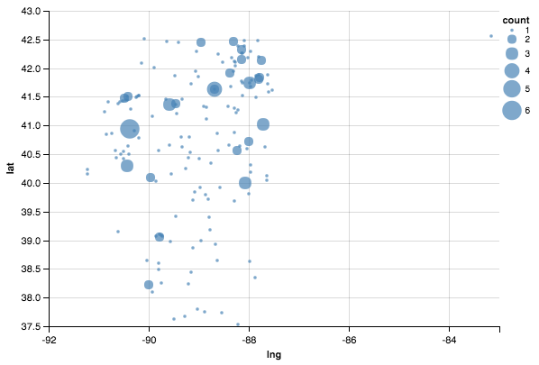

```python
ar.Chart(geo_percentile).mark_circle().encode(
    ar.X('lng', scale=ar.Scale(zero=False)),
    ar.Y('lat', scale=ar.Scale(zero=False)),
    size='count'
)
```